# Final Project - Stock Price Prediction

Kyle Lee 2018/12/10

## 1. EDA and Data Preparation

```python
import numpy as np
import pandas as pd
from datetime import datetime
from sklearn.preprocessing import StandardScaler
from matplotlib.pyplot import figure
from sklearn import metrics
import matplotlib.pyplot as plt
```

```python
#import data
data=pd.read_csv("stock.csv")
data.head()
```

|  | Start Date | 1/1/1960 | Unnamed: 2 | Unnamed: 3 | Unnamed: 4 | Unnamed: 5 | Unnamed: 6 | Unnamed: 7 | Unnamed: 8 | Unnamed: 9 |
| --- | --- | --- | --- | --- | --- | --- | --- | --- | --- | --- |
| 0 | End Date | NaN | NaN | NaN | NaN | NaN | NaN | NaN | NaN | NaN |
| 1 | NaN | NaN | NaN | NaN | NaN | NaN | NaN | NaN | NaN | NaN |
| 2 | NaN | SPX Index | VIX Index | USGG10YR Index | USGG2YR Index | USGG5YR Index | XAU Curncy | CL1 Comdty | USURTOT Index | GDP CQOQ Index |
| 3 | NaN | Last Price | Last Price | Last Price | Last Price | Last Price | Last Price | Last Price | Last Price | Last Price |
| 4 | Dates | PX_LAST | PX_LAST | PX_LAST | PX_LAST | PX_LAST | PX_LAST | PX_LAST | PX_LAST | PX_LAST |

```python
#Delete first row, since it's all NaNs
data=data.iloc[2:,]
data.head()
```

|  | Start Date | 1/1/1960 | Unnamed: 2 | Unnamed: 3 | Unnamed: 4 | Unnamed: 5 | Unnamed: 6 | Unnamed: 7 | Unnamed: 8 | Unnamed: 9 |
| --- | --- | --- | --- | --- | --- | --- | --- | --- | --- | --- |
| 2 | NaN | SPX Index | VIX Index | USGG10YR Index | USGG2YR Index | USGG5YR Index | XAU Curncy | CL1 Comdty | USURTOT Index | GDP CQOQ Index |
| 3 | NaN | Last Price | Last Price | Last Price | Last Price | Last Price | Last Price | Last Price | Last Price | Last Price |
| 4 | Dates | PX_LAST | PX_LAST | PX_LAST | PX_LAST | PX_LAST | PX_LAST | PX_LAST | PX_LAST | PX_LAST |
| 5 | 1/1/1960 | NaN | NaN | NaN | NaN | NaN | NaN | NaN | NaN | NaN |
| 6 | 1/4/1960 | 59.91 | NaN | NaN | NaN | NaN | NaN | NaN | NaN | NaN |

```python
#Set the first column as the index, and delete it
data.index=data.iloc[:,0]
data=data.drop(data.columns[0],axis=1)
data.head()
```

| Start Date | 1/1/1960 | Unnamed: 2 | Unnamed: 3 | Unnamed: 4 | Unnamed: 5 | Unnamed: 6 | Unnamed: 7 | Unnamed: 8 | Unnamed: 9 |
| --- | --- | --- | --- | --- | --- | --- | --- | --- | --- |
| NaN | SPX Index | VIX Index | USGG10YR Index | USGG2YR Index | USGG5YR Index | XAU Curncy | CL1 Comdty | USURTOT Index | GDP CQOQ Index |
| NaN | Last Price | Last Price | Last Price | Last Price | Last Price | Last Price | Last Price | Last Price | Last Price |
| Dates | PX_LAST | PX_LAST | PX_LAST | PX_LAST | PX_LAST | PX_LAST | PX_LAST | PX_LAST | PX_LAST |
| 1/1/1960 | NaN | NaN | NaN | NaN | NaN | NaN | NaN | NaN | NaN |
| 1/4/1960 | 59.91 | NaN | NaN | NaN | NaN | NaN | NaN | NaN | NaN |

```python
#set the first row as the column names,and delete them
data.columns=data.iloc[0]
data=data[4:]
data.head()
```

| nan Start Date | SPX Index | VIX Index | USGG10YR Index | USGG2YR Index | USGG5YR Index | XAU Curncy | CL1 Comdty | USURTOT Index | GDP CQOQ Index |
| --- | --- | --- | --- | --- | --- | --- | --- | --- | --- |
| 1/4/1960 | 59.91 | NaN | NaN | NaN | NaN | NaN | NaN | NaN | NaN |
| 1/5/1960 | 60.39 | NaN | NaN | NaN | NaN | NaN | NaN | NaN | NaN |
| 1/6/1960 | 60.13 | NaN | NaN | NaN | NaN | NaN | NaN | NaN | NaN |
| 1/7/1960 | 59.69 | NaN | NaN | NaN | NaN | NaN | NaN | NaN | NaN |
| 1/8/1960 | 59.5 | NaN | NaN | NaN | NaN | NaN | NaN | NaN | NaN |

```python
dates=[]
for i in enumerate(data.index):
    dates=np.append(dates,datetime.strptime(i[1],'%m/%d/%Y'))
data.index=dates
```

```python
for i in range(9):
    print(data.columns[i],"has ",len(data.iloc[:,i].dropna()),"data points")
```

```
SPX Index has  14833 data points
VIX Index has  7286 data points
USGG10YR Index has  14497 data points
USGG2YR Index has  10901 data points
USGG5YR Index has  14473 data points
XAU Curncy has  11435 data points
CL1 Comdty has  8941 data points
USURTOT Index has  504 data points
GDP CQOQ Index has  0 data points
```

```python
data.describe()
```

| nan | SPX Index | VIX Index | USGG10YR Index | USGG2YR Index | USGG5YR Index | XAU Curncy | CL1 Comdty | USURTOT Index | GDP CQOQ Index |
| --- | --- | --- | --- | --- | --- | --- | --- | --- | --- |
| count | 14833 | 7286 | 14497 | 10901 | 14473 | 11435 | 8941 | 504 | 0.0 |
| unique | 12470 | 2369 | 7823 | 7359 | 7771 | 7272 | 4832 | 68 | 0.0 |
| top | 102.09 | 12.42 | 4.202 | 0.25 | 4.154 | 384.5 | 20.48 | 5.4 | NaN |
| freq | 7 | 15 | 77 | 18 | 57 | 17 | 13 | 23 | NaN |

We can see the USURTOT Index and the GDP CQOQ Index has too little data, since they are unemployment and GDP, where they are mostly measured quarterly or yearly, so I decided to drop them

```python
#dropping the last two columns
data2=data.iloc[:,0:7]
data2.head()
```

| nan | SPX Index | VIX Index | USGG10YR Index | USGG2YR Index | USGG5YR Index | XAU Curncy | CL1 Comdty |
| --- | --- | --- | --- | --- | --- | --- | --- |
| 1960-01-04 | 59.91 | NaN | NaN | NaN | NaN | NaN | NaN |
| 1960-01-05 | 60.39 | NaN | NaN | NaN | NaN | NaN | NaN |
| 1960-01-06 | 60.13 | NaN | NaN | NaN | NaN | NaN | NaN |
| 1960-01-07 | 59.69 | NaN | NaN | NaN | NaN | NaN | NaN |
| 1960-01-08 | 59.5 | NaN | NaN | NaN | NaN | NaN | NaN |

```python
#I used dropna instead of fillna()
data2=data2.dropna()
data2.head()
```

| nan | SPX Index | VIX Index | USGG10YR Index | USGG2YR Index | USGG5YR Index | XAU Curncy | CL1 Comdty |
| --- | --- | --- | --- | --- | --- | --- | --- |
| 1990-01-02 | 359.69 | 17.24 | 7.93 | 7.875 | 7.847 | 399 | 22.89 |
| 1990-01-03 | 358.76 | 18.19 | 7.974 | 7.927 | 7.911 | 395 | 23.68 |
| 1990-01-04 | 355.67 | 19.22 | 7.972 | 7.91 | 7.9 | 396.5 | 23.41 |
| 1990-01-05 | 352.2 | 20.11 | 7.984 | 7.885 | 7.896 | 405 | 23.08 |
| 1990-01-08 | 353.79 | 20.26 | 8.012 | 7.893 | 7.907 | 404.6 | 21.62 |

```python
#Creating the y for models, since we are predicting the next day's stock price,
#the target value for this day should be the next day's price
data2['target']=data2["SPX Index"].shift(-1)
data2.head()
```

| nan | SPX Index | VIX Index | USGG10YR Index | USGG2YR Index | USGG5YR Index | XAU Curncy | CL1 Comdty | target |
| --- | --- | --- | --- | --- | --- | --- | --- | --- |
| 1990-01-02 | 359.69 | 17.24 | 7.93 | 7.875 | 7.847 | 399 | 22.89 | 358.76 |
| 1990-01-03 | 358.76 | 18.19 | 7.974 | 7.927 | 7.911 | 395 | 23.68 | 355.67 |
| 1990-01-04 | 355.67 | 19.22 | 7.972 | 7.91 | 7.9 | 396.5 | 23.41 | 352.2 |
| 1990-01-05 | 352.2 | 20.11 | 7.984 | 7.885 | 7.896 | 405 | 23.08 | 353.79 |
| 1990-01-08 | 353.79 | 20.26 | 8.012 | 7.893 | 7.907 | 404.6 | 21.62 | 349.62 |

```python
#making sure there's no na values
data2=data2.dropna()
```

```python
data2
```

| nan | SPX Index | VIX Index | USGG10YR Index | USGG2YR Index | USGG5YR Index | XAU Curncy | CL1 Comdty | target |
| --- | --- | --- | --- | --- | --- | --- | --- | --- |
| 1990-01-02 | 359.69 | 17.24 | 7.93 | 7.875 | 7.847 | 399 | 22.89 | 358.76 |
| 1990-01-03 | 358.76 | 18.19 | 7.974 | 7.927 | 7.911 | 395 | 23.68 | 355.67 |
| 1990-01-04 | 355.67 | 19.22 | 7.972 | 7.91 | 7.9 | 396.5 | 23.41 | 352.2 |
| 1990-01-05 | 352.2 | 20.11 | 7.984 | 7.885 | 7.896 | 405 | 23.08 | 353.79 |
| 1990-01-08 | 353.79 | 20.26 | 8.012 | 7.893 | 7.907 | 404.6 | 21.62 | 349.62 |
| 1990-01-09 | 349.62 | 22.2 | 8.009 | 7.893 | 7.903 | 403.45 | 22.07 | 347.31 |
| 1990-01-10 | 347.31 | 22.44 | 8.014 | 7.876 | 7.907 | 409.1 | 22.9 | 348.53 |
| 1990-01-11 | 348.53 | 20.05 | 8.044 | 7.92 | 7.949 | 412.1 | 23.14 | 339.93 |
| 1990-01-12 | 339.93 | 24.64 | 8.096 | 7.938 | 7.983 | 416.25 | 23.13 | 337 |
| 1990-01-15 | 337 | 26.34 | 8.113 | 7.947 | 7.995 | 415.6 | 22.36 | 340.75 |
| 1990-01-16 | 340.75 | 24.18 | 8.196 | 8.098 | 8.106 | 412.75 | 22.78 | 337.4 |
| 1990-01-17 | 337.4 | 24.16 | 8.191 | 8.054 | 8.095 | 410.4 | 22.1 | 338.19 |
| 1990-01-18 | 338.19 | 24.34 | 8.303 | 8.232 | 8.233 | 413.4 | 22.76 | 339.15 |
| 1990-01-19 | 339.15 | 22.5 | 8.232 | 8.162 | 8.164 | 408.65 | 23.67 | 330.38 |
| 1990-01-22 | 330.38 | 26.7 | 8.27 | 8.136 | 8.164 | 406 | 22.55 | 331.61 |
| 1990-01-23 | 331.61 | 24.72 | 8.349 | 8.235 | 8.254 | 408.25 | 21.6 | 330.26 |
| 1990-01-24 | 330.26 | 25.39 | 8.366 | 8.235 | 8.269 | 420.75 | 21.59 | 326.08 |
| 1990-01-25 | 326.08 | 25.63 | 8.413 | 8.246 | 8.305 | 415.65 | 22.24 | 325.8 |
| 1990-01-26 | 325.8 | 26.28 | 8.464 | 8.263 | 8.348 | 418 | 22.56 | 325.2 |
| 1990-01-29 | 325.2 | 26.44 | 8.535 | 8.324 | 8.431 | 418.75 | 22.8 | 322.98 |
| 1990-01-30 | 322.98 | 27.25 | 8.501 | 8.28 | 8.388 | 418.15 | 22.46 | 329.08 |
| 1990-01-31 | 329.08 | 25.36 | 8.418 | 8.254 | 8.318 | 415.05 | 22.68 | 328.79 |
| 1990-02-01 | 328.79 | 24.87 | 8.413 | 8.28 | 8.333 | 415.8 | 22.7 | 330.92 |
| 1990-02-02 | 330.92 | 24.32 | 8.494 | 8.341 | 8.409 | 417.95 | 23.02 | 331.85 |
| 1990-02-05 | 331.85 | 24.54 | 8.519 | 8.359 | 8.421 | 423 | 22.39 | 329.66 |
| 1990-02-06 | 329.66 | 24.69 | 8.58 | 8.402 | 8.484 | 421.05 | 22.51 | 333.75 |
| 1990-02-07 | 333.75 | 24.29 | 8.536 | 8.385 | 8.441 | 423.75 | 22.32 | 332.96 |
| 1990-02-08 | 332.96 | 23.77 | 8.429 | 8.315 | 8.378 | 418 | 22.09 | 333.62 |
| 1990-02-09 | 333.62 | 23.69 | 8.29 | 8.218 | 8.261 | 415.5 | 21.74 | 330.08 |
| 1990-02-12 | 330.08 | 24.38 | 8.385 | 8.28 | 8.348 | 418.85 | 22.03 | 331.02 |
| ... | ... | ... | ... | ... | ... | ... | ... | ... |
| 2018-10-19 | 2767.78 | 19.89 | 3.1921 | 2.9038 | 3.0463 | 1226.49 | 69.12 | 2755.88 |
| 2018-10-22 | 2755.88 | 19.64 | 3.1978 | 2.9082 | 3.0498 | 1222.1 | 69.17 | 2740.69 |
| 2018-10-23 | 2740.69 | 20.71 | 3.1676 | 2.879 | 3.012 | 1230.3 | 66.43 | 2656.1 |
| 2018-10-24 | 2656.1 | 25.23 | 3.1035 | 2.8305 | 2.9398 | 1233.79 | 66.82 | 2705.57 |
| 2018-10-25 | 2705.57 | 24.22 | 3.1167 | 2.8467 | 2.9596 | 1232.17 | 67.33 | 2658.69 |
| 2018-10-26 | 2658.69 | 24.16 | 3.0755 | 2.8062 | 2.9071 | 1233.53 | 67.59 | 2641.25 |
| 2018-10-29 | 2641.25 | 24.7 | 3.0849 | 2.8164 | 2.919 | 1229.42 | 67.04 | 2682.63 |
| 2018-10-30 | 2682.63 | 23.35 | 3.1227 | 2.8507 | 2.9562 | 1222.93 | 66.18 | 2711.74 |
| 2018-10-31 | 2711.74 | 21.23 | 3.1435 | 2.8669 | 2.9749 | 1214.76 | 65.31 | 2740.37 |
| 2018-11-01 | 2740.37 | 19.34 | 3.1303 | 2.8445 | 2.9563 | 1233.43 | 63.69 | 2723.06 |
| 2018-11-02 | 2723.06 | 19.51 | 3.2121 | 2.9034 | 3.033 | 1232.89 | 63.14 | 2738.31 |
| 2018-11-05 | 2738.31 | 19.96 | 3.2008 | 2.9075 | 3.028 | 1231.49 | 63.1 | 2755.45 |
| 2018-11-06 | 2755.45 | 19.91 | 3.2276 | 2.9279 | 3.0554 | 1227.19 | 62.21 | 2813.89 |
| 2018-11-07 | 2813.89 | 16.36 | 3.2355 | 2.9567 | 3.0795 | 1226.49 | 61.67 | 2806.83 |
| 2018-11-08 | 2806.83 | 16.72 | 3.2373 | 2.965 | 3.0916 | 1224 | 60.67 | 2781.01 |
| 2018-11-09 | 2781.01 | 17.36 | 3.1819 | 2.9241 | 3.0353 | 1209.65 | 60.19 | 2726.22 |
| 2018-11-12 | 2726.22 | 20.45 | 3.1819 | 2.9241 | 3.0353 | 1200.37 | 59.93 | 2722.18 |
| 2018-11-13 | 2722.18 | 20.02 | 3.1397 | 2.8911 | 2.984 | 1202.23 | 55.69 | 2701.58 |
| 2018-11-14 | 2701.58 | 21.25 | 3.125 | 2.8663 | 2.9567 | 1210.88 | 56.25 | 2730.2 |
| 2018-11-15 | 2730.2 | 19.98 | 3.1103 | 2.8539 | 2.9379 | 1213.36 | 56.46 | 2736.27 |
| 2018-11-16 | 2736.27 | 18.14 | 3.0628 | 2.7998 | 2.8782 | 1223.36 | 56.46 | 2690.73 |
| 2018-11-19 | 2690.73 | 20.1 | 3.0628 | 2.7893 | 2.8697 | 1224.17 | 56.76 | 2641.89 |
| 2018-11-20 | 2641.89 | 22.48 | 3.0628 | 2.8037 | 2.8867 | 1221.66 | 53.43 | 2649.93 |
| 2018-11-21 | 2649.93 | 20.8 | 3.0627 | 2.8139 | 2.8901 | 1226.04 | 54.63 | 2632.56 |
| 2018-11-23 | 2632.56 | 21.52 | 3.039 | 2.8094 | 2.8662 | 1223.05 | 50.42 | 2673.45 |
| 2018-11-26 | 2673.45 | 18.9 | 3.0535 | 2.8302 | 2.885 | 1222.4 | 51.63 | 2682.17 |
| 2018-11-27 | 2682.17 | 19.02 | 3.0572 | 2.8329 | 2.8901 | 1215.05 | 51.56 | 2743.79 |
| 2018-11-28 | 2743.79 | 18.49 | 3.059 | 2.8086 | 2.8649 | 1221.23 | 50.29 | 2737.76 |
| 2018-11-29 | 2737.76 | 18.79 | 3.0298 | 2.8086 | 2.8463 | 1224.21 | 51.45 | 2760.17 |
| 2018-11-30 | 2760.17 | 18.07 | 2.9879 | 2.7865 | 2.8125 | 1220.52 | 50.93 | 2789.64 |

7228 rows × 8 columns

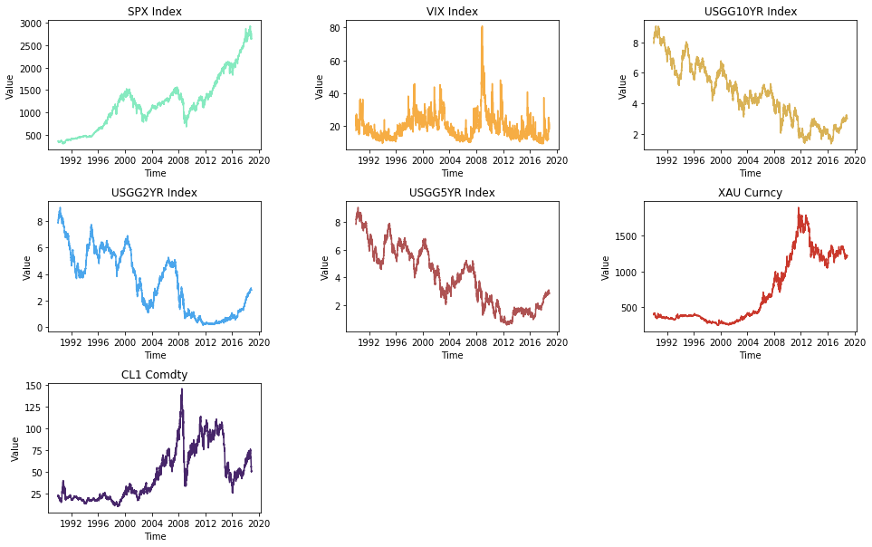

```python
fig = plt.figure(figsize=(16,10))
fig.subplots_adjust(hspace=0.4, wspace=0.4)
for j in range(7):
    ax= fig.add_subplot(3,3,j+1)
    y=np.array(data2[data2.columns[j]])
    y=[float(i) for i in y]
    x=data2[data2.columns[j]].index
    ax.plot(x,y,c=np.random.rand(3))
    ax.set_title(data2.columns[j])
    ax.set_ylabel('Value')
    ax.set_xlabel('Time')
plt.show()
```

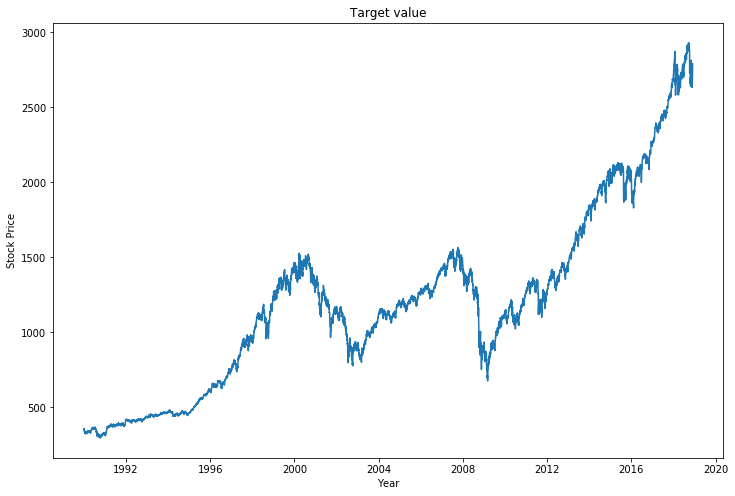

```python
#briefly plot the data for SPY
y=np.array(data2['target'])
y=[float(i) for i in y]
x=data2['target'].index
figure(figsize=(12,8))
plt.plot(x,y)
plt.title('Target value')
plt.xlabel('Year')
plt.ylabel('Stock Price')
plt.show()
```

## 2. Prepare X, y for training

Get the X and y ready for implementing machine learning models Also I decided to try out both regression and classification

```python
X_data=np.array(data2.drop(['SPX Index', 'target'],axis=1))
# X_data=[float(i) for i in X_data]
X_data=X_data.astype(float)
print("Shape of X_data is: ", X_data.shape,'\nSneak peek on first five elements: \n', X_data[0:5])
```

```
Shape of X_data is:  (7228, 6)
Sneak peek on first five elements:
 [[ 17.24    7.93    7.875   7.847 399.     22.89 ]
 [ 18.19    7.974   7.927   7.911 395.     23.68 ]
 [ 19.22    7.972   7.91    7.9   396.5    23.41 ]
 [ 20.11    7.984   7.885   7.896 405.     23.08 ]
 [ 20.26    8.012   7.893   7.907 404.6    21.62 ]]
```

```python
y_data=np.array(data2.target)
y_data=[float(i) for i in y_data]
print("Length of y_data is :", len(y_data),'\nSneak peek on first five elements: \n', y_data[0:5])
```

```
Length of y_data is : 7228
Sneak peek on first five elements:
 [358.76, 355.67, 352.2, 353.79, 349.62]
```

```python
#Turning it into classification
data_f=data2.astype(float)
data_f.head()
```

| nan | SPX Index | VIX Index | USGG10YR Index | USGG2YR Index | USGG5YR Index | XAU Curncy | CL1 Comdty | target |
| --- | --- | --- | --- | --- | --- | --- | --- | --- |
| 1990-01-02 | 359.69 | 17.24 | 7.930 | 7.875 | 7.847 | 399.0 | 22.89 | 358.76 |
| 1990-01-03 | 358.76 | 18.19 | 7.974 | 7.927 | 7.911 | 395.0 | 23.68 | 355.67 |
| 1990-01-04 | 355.67 | 19.22 | 7.972 | 7.910 | 7.900 | 396.5 | 23.41 | 352.20 |
| 1990-01-05 | 352.20 | 20.11 | 7.984 | 7.885 | 7.896 | 405.0 | 23.08 | 353.79 |
| 1990-01-08 | 353.79 | 20.26 | 8.012 | 7.893 | 7.907 | 404.6 | 21.62 | 349.62 |

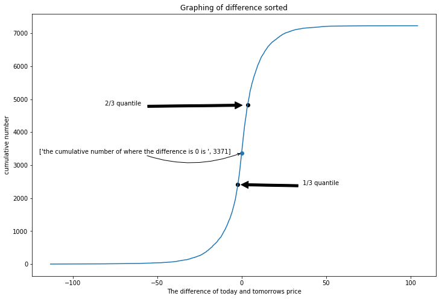

```python
data_f['diff']=data_f['target']-data_f['SPX Index']
sorted_diff=np.sort(data_f['diff'])
leng=len(data_f['diff'])
figure(figsize=(12,8))
plt.plot(sorted_diff,range(leng))
plt.scatter(sorted_diff[int(leng/3)],int(leng/3),c='black')
plt.scatter(sorted_diff[int(leng*2/3)],int(leng*2/3),c='black')
plt.scatter(sorted_diff[sorted_diff>0][0],np.argwhere(sorted_diff>0)[0])
plt.annotate(['the cumulative number of where the difference is 0 is ',int(np.argwhere(sorted_diff>0)[0])],
             xy=(sorted_diff[sorted_diff>0][0],np.argwhere(sorted_diff>0)[0]),
            xytext=(-120,np.argwhere(sorted_diff>0)[0]),arrowprops=dict(arrowstyle='->',connectionstyle="arc3,rad=.2"))
plt.annotate('1/3 quantile',xy=(sorted_diff[int(leng/3)],int(leng/3)),
             xytext=(36,int(leng/3)),arrowprops=dict(facecolor='black',shrink=0.05))
plt.annotate('2/3 quantile',xy=(sorted_diff[int(leng*(2/3))],int(leng*(2/3))),
             xytext=(-81,int(leng*2/3)),arrowprops=dict(facecolor='black',shrink=0.05))
plt.xlabel('The difference of today and tomorrows price')
plt.ylabel('cumulative number')
plt.title('Graphing of difference sorted')
plt.show()
```

Creating classification

```python
data_f['classify']=1
data_f['classify'].loc[((data_f['diff']>data_f['diff'].quantile(2/3)) & (data_f['diff']>0))]=2
data_f['classify'].loc[((data_f['diff']<data_f['diff'].quantile(1/3)) & (data_f['diff']<0))]=0
data_f
```

| nan | SPX Index | VIX Index | USGG10YR Index | USGG2YR Index | USGG5YR Index | XAU Curncy | CL1 Comdty | target | diff | classify |
| --- | --- | --- | --- | --- | --- | --- | --- | --- | --- | --- |
| 1990-01-02 | 359.69 | 17.24 | 7.9300 | 7.8750 | 7.8470 | 399.00 | 22.89 | 358.76 | -0.93 | 1 |
| 1990-01-03 | 358.76 | 18.19 | 7.9740 | 7.9270 | 7.9110 | 395.00 | 23.68 | 355.67 | -3.09 | 0 |
| 1990-01-04 | 355.67 | 19.22 | 7.9720 | 7.9100 | 7.9000 | 396.50 | 23.41 | 352.20 | -3.47 | 0 |
| 1990-01-05 | 352.20 | 20.11 | 7.9840 | 7.8850 | 7.8960 | 405.00 | 23.08 | 353.79 | 1.59 | 1 |
| 1990-01-08 | 353.79 | 20.26 | 8.0120 | 7.8930 | 7.9070 | 404.60 | 21.62 | 349.62 | -4.17 | 0 |
| 1990-01-09 | 349.62 | 22.20 | 8.0090 | 7.8930 | 7.9030 | 403.45 | 22.07 | 347.31 | -2.31 | 0 |
| 1990-01-10 | 347.31 | 22.44 | 8.0140 | 7.8760 | 7.9070 | 409.10 | 22.90 | 348.53 | 1.22 | 1 |
| 1990-01-11 | 348.53 | 20.05 | 8.0440 | 7.9200 | 7.9490 | 412.10 | 23.14 | 339.93 | -8.60 | 0 |
| 1990-01-12 | 339.93 | 24.64 | 8.0960 | 7.9380 | 7.9830 | 416.25 | 23.13 | 337.00 | -2.93 | 0 |
| 1990-01-15 | 337.00 | 26.34 | 8.1130 | 7.9470 | 7.9950 | 415.60 | 22.36 | 340.75 | 3.75 | 2 |
| 1990-01-16 | 340.75 | 24.18 | 8.1960 | 8.0980 | 8.1060 | 412.75 | 22.78 | 337.40 | -3.35 | 0 |
| 1990-01-17 | 337.40 | 24.16 | 8.1910 | 8.0540 | 8.0950 | 410.40 | 22.10 | 338.19 | 0.79 | 1 |
| 1990-01-18 | 338.19 | 24.34 | 8.3030 | 8.2320 | 8.2330 | 413.40 | 22.76 | 339.15 | 0.96 | 1 |
| 1990-01-19 | 339.15 | 22.50 | 8.2320 | 8.1620 | 8.1640 | 408.65 | 23.67 | 330.38 | -8.77 | 0 |
| 1990-01-22 | 330.38 | 26.70 | 8.2700 | 8.1360 | 8.1640 | 406.00 | 22.55 | 331.61 | 1.23 | 1 |
| 1990-01-23 | 331.61 | 24.72 | 8.3490 | 8.2350 | 8.2540 | 408.25 | 21.60 | 330.26 | -1.35 | 1 |
| 1990-01-24 | 330.26 | 25.39 | 8.3660 | 8.2350 | 8.2690 | 420.75 | 21.59 | 326.08 | -4.18 | 0 |
| 1990-01-25 | 326.08 | 25.63 | 8.4130 | 8.2460 | 8.3050 | 415.65 | 22.24 | 325.80 | -0.28 | 1 |
| 1990-01-26 | 325.80 | 26.28 | 8.4640 | 8.2630 | 8.3480 | 418.00 | 22.56 | 325.20 | -0.60 | 1 |
| 1990-01-29 | 325.20 | 26.44 | 8.5350 | 8.3240 | 8.4310 | 418.75 | 22.80 | 322.98 | -2.22 | 1 |
| 1990-01-30 | 322.98 | 27.25 | 8.5010 | 8.2800 | 8.3880 | 418.15 | 22.46 | 329.08 | 6.10 | 2 |
| 1990-01-31 | 329.08 | 25.36 | 8.4180 | 8.2540 | 8.3180 | 415.05 | 22.68 | 328.79 | -0.29 | 1 |
| 1990-02-01 | 328.79 | 24.87 | 8.4130 | 8.2800 | 8.3330 | 415.80 | 22.70 | 330.92 | 2.13 | 1 |
| 1990-02-02 | 330.92 | 24.32 | 8.4940 | 8.3410 | 8.4090 | 417.95 | 23.02 | 331.85 | 0.93 | 1 |
| 1990-02-05 | 331.85 | 24.54 | 8.5190 | 8.3590 | 8.4210 | 423.00 | 22.39 | 329.66 | -2.19 | 1 |
| 1990-02-06 | 329.66 | 24.69 | 8.5800 | 8.4020 | 8.4840 | 421.05 | 22.51 | 333.75 | 4.09 | 2 |
| 1990-02-07 | 333.75 | 24.29 | 8.5360 | 8.3850 | 8.4410 | 423.75 | 22.32 | 332.96 | -0.79 | 1 |
| 1990-02-08 | 332.96 | 23.77 | 8.4290 | 8.3150 | 8.3780 | 418.00 | 22.09 | 333.62 | 0.66 | 1 |
| 1990-02-09 | 333.62 | 23.69 | 8.2900 | 8.2180 | 8.2610 | 415.50 | 21.74 | 330.08 | -3.54 | 0 |
| 1990-02-12 | 330.08 | 24.38 | 8.3850 | 8.2800 | 8.3480 | 418.85 | 22.03 | 331.02 | 0.94 | 1 |
| ... | ... | ... | ... | ... | ... | ... | ... | ... | ... | ... |
| 2018-10-19 | 2767.78 | 19.89 | 3.1921 | 2.9038 | 3.0463 | 1226.49 | 69.12 | 2755.88 | -11.90 | 0 |
| 2018-10-22 | 2755.88 | 19.64 | 3.1978 | 2.9082 | 3.0498 | 1222.10 | 69.17 | 2740.69 | -15.19 | 0 |
| 2018-10-23 | 2740.69 | 20.71 | 3.1676 | 2.8790 | 3.0120 | 1230.30 | 66.43 | 2656.10 | -84.59 | 0 |
| 2018-10-24 | 2656.10 | 25.23 | 3.1035 | 2.8305 | 2.9398 | 1233.79 | 66.82 | 2705.57 | 49.47 | 2 |
| 2018-10-25 | 2705.57 | 24.22 | 3.1167 | 2.8467 | 2.9596 | 1232.17 | 67.33 | 2658.69 | -46.88 | 0 |
| 2018-10-26 | 2658.69 | 24.16 | 3.0755 | 2.8062 | 2.9071 | 1233.53 | 67.59 | 2641.25 | -17.44 | 0 |
| 2018-10-29 | 2641.25 | 24.70 | 3.0849 | 2.8164 | 2.9190 | 1229.42 | 67.04 | 2682.63 | 41.38 | 2 |
| 2018-10-30 | 2682.63 | 23.35 | 3.1227 | 2.8507 | 2.9562 | 1222.93 | 66.18 | 2711.74 | 29.11 | 2 |
| 2018-10-31 | 2711.74 | 21.23 | 3.1435 | 2.8669 | 2.9749 | 1214.76 | 65.31 | 2740.37 | 28.63 | 2 |
| 2018-11-01 | 2740.37 | 19.34 | 3.1303 | 2.8445 | 2.9563 | 1233.43 | 63.69 | 2723.06 | -17.31 | 0 |
| 2018-11-02 | 2723.06 | 19.51 | 3.2121 | 2.9034 | 3.0330 | 1232.89 | 63.14 | 2738.31 | 15.25 | 2 |
| 2018-11-05 | 2738.31 | 19.96 | 3.2008 | 2.9075 | 3.0280 | 1231.49 | 63.10 | 2755.45 | 17.14 | 2 |
| 2018-11-06 | 2755.45 | 19.91 | 3.2276 | 2.9279 | 3.0554 | 1227.19 | 62.21 | 2813.89 | 58.44 | 2 |
| 2018-11-07 | 2813.89 | 16.36 | 3.2355 | 2.9567 | 3.0795 | 1226.49 | 61.67 | 2806.83 | -7.06 | 0 |
| 2018-11-08 | 2806.83 | 16.72 | 3.2373 | 2.9650 | 3.0916 | 1224.00 | 60.67 | 2781.01 | -25.82 | 0 |
| 2018-11-09 | 2781.01 | 17.36 | 3.1819 | 2.9241 | 3.0353 | 1209.65 | 60.19 | 2726.22 | -54.79 | 0 |
| 2018-11-12 | 2726.22 | 20.45 | 3.1819 | 2.9241 | 3.0353 | 1200.37 | 59.93 | 2722.18 | -4.04 | 0 |
| 2018-11-13 | 2722.18 | 20.02 | 3.1397 | 2.8911 | 2.9840 | 1202.23 | 55.69 | 2701.58 | -20.60 | 0 |
| 2018-11-14 | 2701.58 | 21.25 | 3.1250 | 2.8663 | 2.9567 | 1210.88 | 56.25 | 2730.20 | 28.62 | 2 |
| 2018-11-15 | 2730.20 | 19.98 | 3.1103 | 2.8539 | 2.9379 | 1213.36 | 56.46 | 2736.27 | 6.07 | 2 |
| 2018-11-16 | 2736.27 | 18.14 | 3.0628 | 2.7998 | 2.8782 | 1223.36 | 56.46 | 2690.73 | -45.54 | 0 |
| 2018-11-19 | 2690.73 | 20.10 | 3.0628 | 2.7893 | 2.8697 | 1224.17 | 56.76 | 2641.89 | -48.84 | 0 |
| 2018-11-20 | 2641.89 | 22.48 | 3.0628 | 2.8037 | 2.8867 | 1221.66 | 53.43 | 2649.93 | 8.04 | 2 |
| 2018-11-21 | 2649.93 | 20.80 | 3.0627 | 2.8139 | 2.8901 | 1226.04 | 54.63 | 2632.56 | -17.37 | 0 |
| 2018-11-23 | 2632.56 | 21.52 | 3.0390 | 2.8094 | 2.8662 | 1223.05 | 50.42 | 2673.45 | 40.89 | 2 |
| 2018-11-26 | 2673.45 | 18.90 | 3.0535 | 2.8302 | 2.8850 | 1222.40 | 51.63 | 2682.17 | 8.72 | 2 |
| 2018-11-27 | 2682.17 | 19.02 | 3.0572 | 2.8329 | 2.8901 | 1215.05 | 51.56 | 2743.79 | 61.62 | 2 |
| 2018-11-28 | 2743.79 | 18.49 | 3.0590 | 2.8086 | 2.8649 | 1221.23 | 50.29 | 2737.76 | -6.03 | 0 |
| 2018-11-29 | 2737.76 | 18.79 | 3.0298 | 2.8086 | 2.8463 | 1224.21 | 51.45 | 2760.17 | 22.41 | 2 |
| 2018-11-30 | 2760.17 | 18.07 | 2.9879 | 2.7865 | 2.8125 | 1220.52 | 50.93 | 2789.64 | 29.47 | 2 |

7228 rows × 10 columns

```python
text=['The trend is going down: ','The trend is staying the same: ','The trend is going up : ']
for i in range(3):
    print(text[i],sum(data_f['classify']==i))
```

```
The trend is going down:  2408
The trend is staying the same:  2411
The trend is going up :  2409
```

X_data remains the same for classifier, but y_data would be the 'classify' in the last column of the dataframe

```python
y_data_class=np.array(data_f.classify)
print("Length of y_data is :", len(y_data_class),'\nSneak peek on first five elements: \n', y_data_class[0:5])
```

```
Length of y_data is : 7228
Sneak peek on first five elements:
 [1 0 0 1 0]
```

Standardize data and split into train test data

```python
X_train=np.array(X_data[0:int(0.8*len(X_data))])
y_train=np.array(y_data[0:int(0.8*len(y_data))])
y_train_class=np.array(y_data_class[0:int(0.8*len(y_data_class))])
X_test=np.array(X_data[int(0.8*len(X_data)):])
y_test=np.array(y_data[int(0.8*len(y_data)):])
y_test_class=np.array(y_data_class[int(0.8*len(y_data_class)):])
```

```python
#Data Scaling
sc=StandardScaler()
sc2=StandardScaler()
X_train=sc.fit_transform(X_train)
X_test=sc.transform(X_test)
y_train=sc2.fit_transform(y_train.reshape(-1,1))
y_test=sc2.transform(y_test.reshape(-1,1))
X_data_sc=sc.fit_transform(X_data)
y_data_sc=sc.fit_transform(np.array(y_data).reshape(-1,1))
```

## 3. Machine Learning methods

Linear Regression

```python
from sklearn import linear_model
model=linear_model.LinearRegression()
model.fit(X_train,y_train)
```

```
LinearRegression(copy_X=True, fit_intercept=True, n_jobs=1, normalize=False)
```

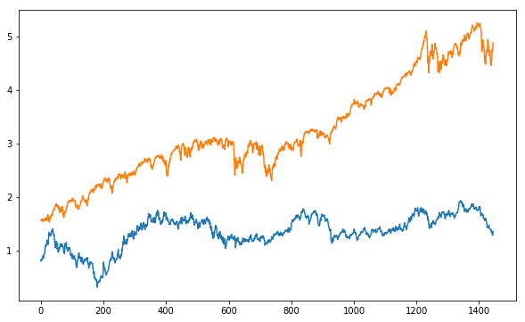

```python
#fit data to model and graph results
y_pred=model.predict(X_test)
figure(figsize=(10,6))
plt.plot(y_pred)
plt.plot(y_test)
plt.show()
```

```python
print("RMSE of test set: ",np.sqrt(metrics.mean_squared_error(y_test,y_pred)))
```

```
RMSE of test set:  2.01655443941397
```

Since it looks completely off, I wanted to check train data

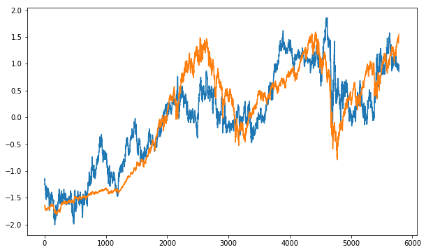

```python
predictions=model.predict(X_train)
figure(figsize=(10,6))
plt.plot(predictions)
plt.plot(y_train)
plt.show()
```

```python
print("RMSE of train set: ",np.sqrt(metrics.mean_squared_error(y_train,predictions)))
```

```
RMSE of train set:  0.47315506396143053
```

Which actually looks decent.

Lasso Regression

```python
clf = linear_model.Lasso(alpha=0.2)
clf.fit(X_train,y_train)
```

```
Lasso(alpha=0.2, copy_X=True, fit_intercept=True, max_iter=1000,
   normalize=False, positive=False, precompute=False, random_state=None,
   selection='cyclic', tol=0.0001, warm_start=False)
```

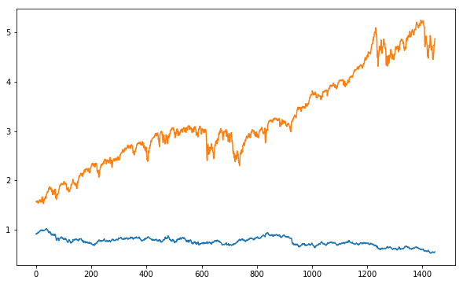

```
RMSE of LASSO on test set:  2.659531397249428
```

```python
#fit data to model and graph results
y_pred=clf.predict(X_test)
figure(figsize=(10,6))
plt.plot(y_pred)
plt.plot(y_test)
plt.show()
print("RMSE of LASSO on test set: ",np.sqrt(metrics.mean_squared_error(y_test,y_pred)))
```

We can see that using LASSO gives us a higher RMSE, since LASSO performs variable selection, thus lowering the explanitory power(also if we change the alpha to 1, the prediction drops flat)

Logistic Regression

```python
lr=linear_model.LogisticRegression(multi_class='multinomial',solver='newton-cg')
lr.fit(X_train,y_train_class)
```

```
LogisticRegression(C=1.0, class_weight=None, dual=False, fit_intercept=True,
          intercept_scaling=1, max_iter=100, multi_class='multinomial',
          n_jobs=1, penalty='l2', random_state=None, solver='newton-cg',
          tol=0.0001, verbose=0, warm_start=False)
```

```python
y_pred=lr.predict(X_test)
```

```
[[ 20 274 250]
 [  9 183 103]
 [ 30 284 293]]
```

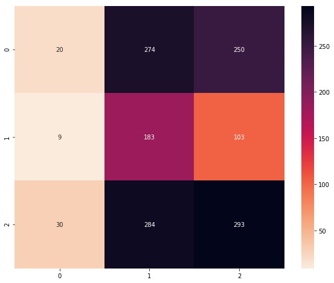

```python
cm=metrics.confusion_matrix(y_test_class,y_pred)
print(cm)
import seaborn as sn
cmap = sn.cm.rocket_r
plt.figure(figsize=(10,8))
sn.heatmap(cm, annot=True,cmap=cmap,fmt='g')
plt.show()
```

```python
from sklearn.metrics import classification_report
print(classification_report(y_test_class, y_pred))
```

```
             precision    recall  f1-score   support

          0       0.34      0.04      0.07       544
          1       0.25      0.62      0.35       295
          2       0.45      0.48      0.47       607

avg / total       0.37      0.34      0.29      1446
```

We can see that the prediction for the [2] is the best, but it doensn't predict price decrease well. Also all three scores are low. So I tried gridsearch to find better parameters

```python
from sklearn.model_selection import GridSearchCV
params={'C': [100,10,1,.01,.001]}
y_pred=lr.predict(X_test)
```

```python
gs = GridSearchCV(lr, params, n_jobs=-1)
gs.fit(X_train, y_train_class)
```

```
GridSearchCV(cv=None, error_score='raise',
       estimator=LogisticRegression(C=1.0, class_weight=None, dual=False, fit_intercept=True,
          intercept_scaling=1, max_iter=100, multi_class='multinomial',
          n_jobs=1, penalty='l2', random_state=None, solver='newton-cg',
          tol=0.0001, verbose=0, warm_start=False),
       fit_params=None, iid=True, n_jobs=-1,
       param_grid={'C': [100, 10, 1, 0.01, 0.001]},
       pre_dispatch='2*n_jobs', refit=True, return_train_score='warn',
       scoring=None, verbose=0)
```

```python
gs.best_params_
```

```
{'C': 0.001}
```

```python
y_pred = gs.predict(X_test)
```

```
[[  0 122 422]
 [  0 100 195]
 [  0 150 457]]
```

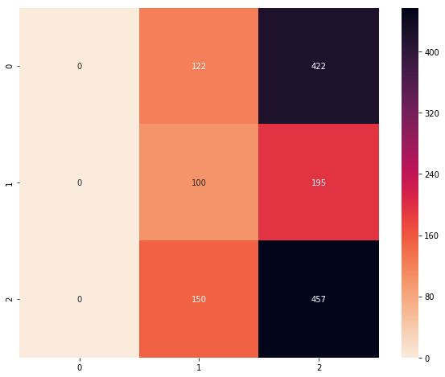

```python
cm=metrics.confusion_matrix(y_test_class,y_pred)
print(cm)
import seaborn as sn
cmap = sn.cm.rocket_r
plt.figure(figsize=(10,8))
sn.heatmap(cm, annot=True,cmap=cmap,fmt='g')
plt.show()
```

```python
from sklearn.metrics import classification_report
print(classification_report(y_test_class, y_pred))
```

```
             precision    recall  f1-score   support

          0       0.00      0.00      0.00       544
          1       0.27      0.34      0.30       295
          2       0.43      0.75      0.54       607

avg / total       0.23      0.39      0.29      1446
```

SVM

```python
from sklearn.svm import SVR
svr=SVR(kernel='rbf', C=1000, gamma=0.1)
svr.fit(X_train,y_train.ravel())
```

```
SVR(C=1000, cache_size=200, coef0=0.0, degree=3, epsilon=0.1, gamma=0.1,
  kernel='rbf', max_iter=-1, shrinking=True, tol=0.001, verbose=False)
```

```python
y_pred=svr.predict(X_test)
```

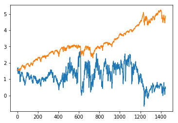

```
RMSE of SVR on test set:  2.3378401543996925
```

```python
plt.plot(y_pred)
plt.plot(y_test)
plt.show()
print("RMSE of SVR on test set: ",np.sqrt(metrics.mean_squared_error(y_test,y_pred)))
```

SVC

```python
from sklearn.svm import SVC
svc=SVC(kernel='linear',C=1000)
svc.fit(X_train,y_train_class.ravel())
```

```
SVC(C=1000, cache_size=200, class_weight=None, coef0=0.0,
  decision_function_shape='ovr', degree=3, gamma='auto', kernel='linear',
  max_iter=-1, probability=False, random_state=None, shrinking=True,
  tol=0.001, verbose=False)
```

```python
y_pred=svc.predict(X_test)
```

```
[[ 66  72 406]
 [ 53  40 202]
 [ 88  73 446]]
```

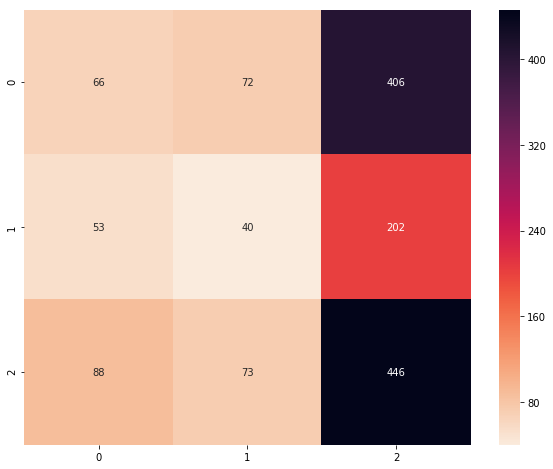

```python
cm=metrics.confusion_matrix(y_test_class,y_pred)
print(cm)
import seaborn as sn
cmap = sn.cm.rocket_r
plt.figure(figsize=(10,8))
sn.heatmap(cm, annot=True,cmap=cmap,fmt='g')
plt.show()
```

```python
from sklearn.metrics import classification_report
print(classification_report(y_test_class, y_pred))
```

```
             precision    recall  f1-score   support

          0       0.32      0.12      0.18       544
          1       0.22      0.14      0.17       295
          2       0.42      0.73      0.54       607

avg / total       0.34      0.38      0.33      1446
```

Again we can see that SVC mostly predicts 2 instead of 0 and 1.

RandomForestClassifier

```python
from sklearn.ensemble import RandomForestRegressor, RandomForestClassifier
```

```python
rfr=RandomForestRegressor(n_estimators=1000,random_state=42, max_features='sqrt',max_depth=150,oob_score=True)
rfr.fit(X_train,y_train.ravel())
```

```
RandomForestRegressor(bootstrap=True, criterion='mse', max_depth=150,
           max_features='sqrt', max_leaf_nodes=None,
           min_impurity_decrease=0.0, min_impurity_split=None,
           min_samples_leaf=1, min_samples_split=2,
           min_weight_fraction_leaf=0.0, n_estimators=1000, n_jobs=1,
           oob_score=True, random_state=42, verbose=0, warm_start=False)
```

```python
y_pred=rfr.predict(X_test)
```

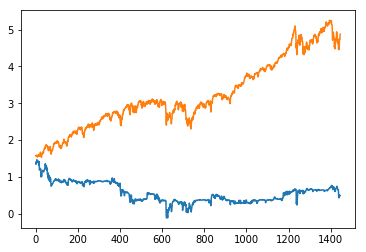

```python
plt.plot(y_pred)
plt.plot(y_test)
plt.show()
```

```python
print("RMSE of randomforest on test set: ",np.sqrt(metrics.mean_squared_error(y_test,y_pred)))
```

```
RMSE of randomforest on test set:  2.855658265912516
```

```python
rfc=RandomForestClassifier(n_estimators=1000,random_state=42, max_features='sqrt',max_depth=50)
rfc.fit(X_train,y_train_class.ravel())
```

```
RandomForestClassifier(bootstrap=True, class_weight=None, criterion='gini',
            max_depth=50, max_features='sqrt', max_leaf_nodes=None,
            min_impurity_decrease=0.0, min_impurity_split=None,
            min_samples_leaf=1, min_samples_split=2,
            min_weight_fraction_leaf=0.0, n_estimators=1000, n_jobs=1,
            oob_score=False, random_state=42, verbose=0, warm_start=False)
```

```python
y_pred=rfc.predict(X_test)
```

```
[[221 206 117]
 [157  98  40]
 [268 193 146]]
```

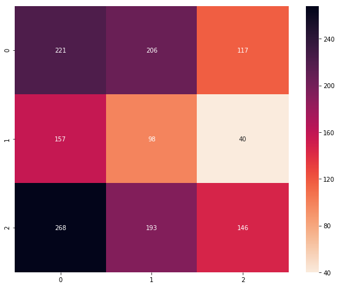

```python
cm=metrics.confusion_matrix(y_test_class,y_pred)
print(cm)
import seaborn as sn
cmap = sn.cm.rocket_r
plt.figure(figsize=(10,8))
sn.heatmap(cm, annot=True,cmap=cmap,fmt='g')
plt.show()
```

```python
from sklearn.metrics import classification_report
print(classification_report(y_test_class, y_pred))
```

```
             precision    recall  f1-score   support

          0       0.34      0.41      0.37       544
          1       0.20      0.33      0.25       295
          2       0.48      0.24      0.32       607

avg / total       0.37      0.32      0.32      1446
```

LightGbm

```python
import lightgbm as lgb
```

```python
d_train=lgb.Dataset(X_train, label=y_train.ravel())

params={}
params['learning_rate']=0.1
params['boosting_type']='gbdt'
params['objective']='regression'
params['sub_feature']=0.5
params['num_leaves']=1024
params['min_data']=50
params['max_depth']=10
params['verbose']=2
```

```python
clf=lgb.train(params, d_train,1000)
```

```python
y_pred=clf.predict(X_test)
```

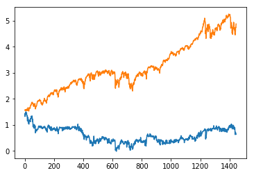

```python
plt.plot(y_pred)
plt.plot(y_test)
plt.show()
```

LightGBM classifier

```python
d_train=lgb.Dataset(X_train, label=y_train_class.ravel())

params={}
params['learning_rate']=0.01
params['boosting_type']='gbdt'
params['objective']='multiclass'
params['sub_feature']=0.5
params['num_leaves']=1024
params['min_data']=50
params['max_depth']=10
params['num_class']=3
```

```python
clf=lgb.train(params, d_train,1000)
```

```python
y_pred=clf.predict(X_test)
```

```python
temp=[]
for i in y_pred:
    temp=np.append(temp,np.argmax(y_pred[0]))
y_pred=np.array(temp)
```

```
[[  0   0 544]
 [  0   0 295]
 [  0   0 607]]
```

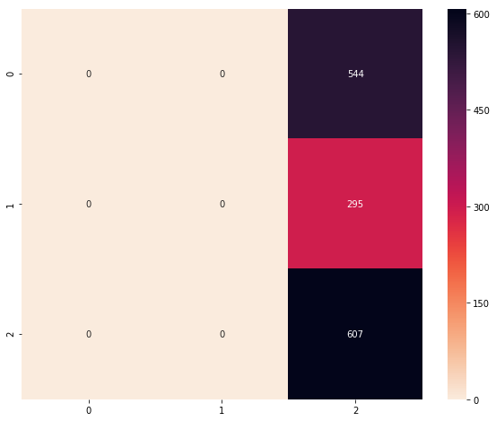

```python
cm=metrics.confusion_matrix(y_test_class,y_pred)
print(cm)
import seaborn as sn
cmap = sn.cm.rocket_r
plt.figure(figsize=(10,8))
sn.heatmap(cm, annot=True,cmap=cmap,fmt='g')
plt.show()
```

```python
print(classification_report(y_test_class, y_pred))
```

```
             precision    recall  f1-score   support

          0       0.00      0.00      0.00       544
          1       0.00      0.00      0.00       295
          2       0.42      1.00      0.59       607

avg / total       0.18      0.42      0.25      1446
```

## Deep learning

1. prepare data

```python
def cut_time(data,stepsize,steplen):
    temp=[]
    times=int((len(data)-steplen)/stepsize)
    for i in range(times):
        temp.append(np.array(data[i*stepsize:i*stepsize+steplen]))
    return np.array(temp)
def cut_time_y(data,stepsize,steplen):
    temp=[]
    times=int((len(data)-steplen)/stepsize)
    for i in range(times):
        temp.append(np.array(data[i*stepsize+steplen]))
    return np.array(temp)
```

```python
sc = StandardScaler()
X_data=sc.fit_transform(X_data)
y_data=sc.fit_transform(np.array(y_data).reshape(-1,1))
features=len(X_data[0])
stepsize=5
steplen=5

X_data2=cut_time(X_data,stepsize,steplen)
X_data2=X_data2.reshape(X_data2.shape[0],steplen,features)
y_data2=cut_time_y(y_data,stepsize,steplen)
y_data2_class=cut_time_y(y_data_class,stepsize,steplen)

X_train=X_data2[0:int(0.6*len(X_data2))]
y_train=y_data2[0:int(0.6*len(y_data2))]
y_train_class=y_data2_class[0:int(0.6*len(y_data2_class))]

X_val=X_data2[int(0.6*len(X_data2)):int(0.8*len(X_data2))]
y_val=y_data2[int(0.6*len(y_data2)):int(0.8*len(y_data2))]
y_val_class=y_data2_class[int(0.6*len(y_data2_class)):int(0.8*len(y_data2_class))]

X_test=X_data2[int(0.8*len(X_data2)):]
y_test=y_data2[int(0.8*len(y_data2)):]
y_test_class=y_data2_class[int(0.8*len(y_data2_class)):]

X_train
```

[output not shown]

[output cut: 12 more lines]

[output not shown]

```python
# one hot encode
from keras.utils import to_categorical
y_train_class = to_categorical(np.array(y_train_class))
y_val_class = to_categorical(np.array(y_val_class))
```

```python
y_test_class
```

```
array([1, 2, 0, 2, 0, 0, 2, 0, 2, 2, 2, 1, 2, 1, 2, 0, 2, 2, 0, 0, 1, 0,
       2, 2, 0, 2, 2, 2, 0, 1, 1, 2, 0, 0, 2, 2, 0, 2, 0, 0, 1, 1, 0, 0,
       2, 2, 2, 2, 0, 1, 1, 1, 0, 0, 2, 2, 2, 1, 1, 0, 0, 2, 2, 2, 2, 1,
       2, 0, 2, 0, 1, 2, 2, 2, 2, 1, 0, 2, 0, 0, 0, 1, 2, 2, 0, 1, 2, 0,
       2, 0, 2, 1, 1, 0, 2, 2, 2, 0, 1, 2, 0, 0, 0, 0, 0, 2, 2, 2, 0, 0,
       1, 1, 0, 0, 2, 2, 0, 1, 2, 1, 0, 0, 0, 2, 0, 1, 0, 0, 2, 0, 2, 1,
       1, 0, 2, 0, 2, 0, 2, 0, 2, 2, 0, 0, 2, 2, 2, 0, 2, 2, 0, 1, 0, 1,
       2, 0, 2, 2, 2, 0, 2, 0, 2, 1, 2, 0, 0, 2, 1, 2, 0, 1, 1, 2, 2, 0,
       1, 0, 0, 0, 2, 0, 1, 1, 0, 0, 0, 0, 0, 2, 0, 2, 2, 2, 2, 0, 1, 1,
       2, 1, 2, 1, 2, 0, 1, 0, 1, 2, 2, 2, 1, 2, 2, 0, 0, 2, 0, 0, 2, 2,
       2, 1, 1, 1, 1, 0, 2, 1, 0, 0, 1, 2, 0, 1, 1, 1, 0, 2, 2, 0, 2, 2,
       1, 2, 2, 2, 1, 1, 0, 2, 1, 0, 2, 1, 0, 2, 0, 0, 0, 1, 2, 2, 0, 0,
       2, 1, 0, 0, 2, 2, 2, 2, 2, 2, 2, 2, 1, 0, 1, 2, 0, 1, 0, 1, 0, 2,
       2, 0, 2], dtype=int64)
```

```python
import tensorflow as tf
```

```python
import keras
from keras.layers import Dense, Flatten, BatchNormalization,Dropout, Input, merge, concatenate,add
from keras.layers import Conv1D, MaxPooling1D, Conv2D, MaxPooling2D, LSTM
from keras.layers import Activation
from keras.models import Sequential
from keras.optimizers import Adam, rmsprop, sgd
from keras import backend as K
from keras.layers.advanced_activations import LeakyReLU, PReLU, ReLU
from keras.callbacks import ReduceLROnPlateau,EarlyStopping
from keras.models import Model
```

```python
X_train.shape
```

```
(866, 5, 6)
```

CNN 1D

```python
inputs=Input(X_train.shape[1:])
x=Dense(32)(inputs)
x=Conv1D(16,kernel_size=3,strides=1)(x)
x=BatchNormalization()(x)
# x=ReLU()(x)

# x1=Conv1D(16,4)(x)
# x=LeakyReLU(alpha=0.1)(x1)

# x2=MaxPooling1D(pool_size=1)(x)
# x=concatenate([x1,x2])
x=Flatten()(x)
# x=Dense(32,name='my16')(x)

predictions=Dense(3, activation='softmax')(x)
model=Model(inputs=inputs, outputs=predictions)
model.compile(optimizer=Adam(lr=0.0001), loss='categorical_crossentropy', metrics=['accuracy'])
model.summary()
history=model.fit(X_train,y_train_class, batch_size=256, epochs=1000, verbose=1,
                 validation_data=(X_val,y_val_class))
#                  callbacks=[ReduceLROnPlateau(monitor='acc',factor=0.2, patience=5, min_lr= 0.00001),EarlyStopping(monitor='acc',patience=7)])
```

```
_________________________________________________________________
Layer (type)                 Output Shape              Param #
=================================================================
input_1 (InputLayer)         (None, 5, 6)              0
_________________________________________________________________
dense_1 (Dense)              (None, 5, 32)             224
_________________________________________________________________
conv1d_1 (Conv1D)            (None, 3, 16)             1552
_________________________________________________________________
batch_normalization_1 (Batch (None, 3, 16)             64
_________________________________________________________________
flatten_1 (Flatten)          (None, 48)                0
_________________________________________________________________
dense_2 (Dense)              (None, 3)                 147
=================================================================
Total params: 1,987
Trainable params: 1,955
Non-trainable params: 32
_________________________________________________________________
Train on 866 samples, validate on 289 samples
```

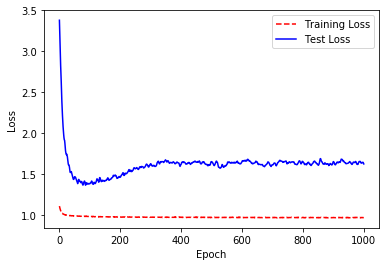

```python
# Get training and test loss histories
training_loss = history.history['loss']
test_loss = history.history['val_loss']

# Create count of the number of epochs
epoch_count = range(1, len(training_loss) + 1)

# Visualize loss history
plt.plot(epoch_count, training_loss, 'r--')
plt.plot(epoch_count, test_loss, 'b-')
plt.legend(['Training Loss', 'Test Loss'])
plt.xlabel('Epoch')
plt.ylabel('Loss')
plt.show();
```

```python
y_pred=model.predict(X_test)
```

```python
#since it's the probability, need to change it to the index
y_pred = [ np.argmax(t) for t in y_pred ]
```

```
[[  0  21  83]
 [  0  12  52]
 [  0  17 104]]
```

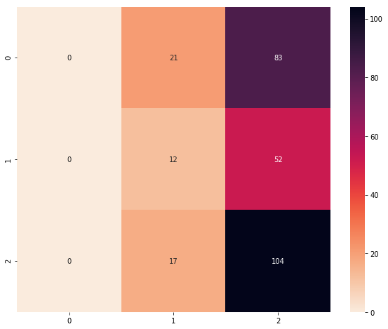

```python
cm=metrics.confusion_matrix(y_test_class,y_pred)
print(cm)
import seaborn as sn
cmap = sn.cm.rocket_r
plt.figure(figsize=(10,8))
sn.heatmap(cm, annot=True,cmap=cmap,fmt='g')
plt.show()
```

```python
print(classification_report(y_test_class, y_pred))
```

```
             precision    recall  f1-score   support

          0       0.00      0.00      0.00       104
          1       0.24      0.19      0.21        64
          2       0.44      0.86      0.58       121

avg / total       0.24      0.40      0.29       289
```

```python
#if you want to keep training
# history=model.fit(X_train,y_train_class, batch_size=256, epochs=1000, verbose=1, validation_data=(X_val,y_val_class))
```

Regression CNN 1D

```python
inputs=Input(X_train.shape[1:])
x=Dense(32)(inputs)
x=Conv1D(16,kernel_size=3,strides=1)(x)
x=BatchNormalization()(x)
# x=ReLU()(x)

# x1=Conv1D(16,4)(x)
# x=LeakyReLU(alpha=0.1)(x1)

# x2=MaxPooling1D(pool_size=1)(x)
# x=concatenate([x1,x2])
x=Flatten()(x)
# x=Dense(32,name='my16')(x)

predictions=Dense(1, activation='sigmoid')(x)
model=Model(inputs=inputs, outputs=predictions)
model.compile(optimizer=Adam(lr=0.0001), loss='mean_squared_error', metrics=['mse'])
model.summary()
history=model.fit(X_train,y_train, batch_size=256, epochs=500, verbose=1,validation_data=(X_val,y_val))
#                  callbacks=[ReduceLROnPlateau(monitor='acc',factor=0.2, patience=5, min_lr= 0.00001),EarlyStopping(monitor='acc',patience=7)])
```

```
_________________________________________________________________
Layer (type)                 Output Shape              Param #
=================================================================
input_2 (InputLayer)         (None, 5, 6)              0
_________________________________________________________________
dense_3 (Dense)              (None, 5, 32)             224
_________________________________________________________________
conv1d_2 (Conv1D)            (None, 3, 16)             1552
_________________________________________________________________
batch_normalization_2 (Batch (None, 3, 16)             64
_________________________________________________________________
flatten_2 (Flatten)          (None, 48)                0
_________________________________________________________________
dense_4 (Dense)              (None, 1)                 49
=================================================================
Total params: 1,889
Trainable params: 1,857
Non-trainable params: 32
_________________________________________________________________
Train on 866 samples, validate on 289 samples
```

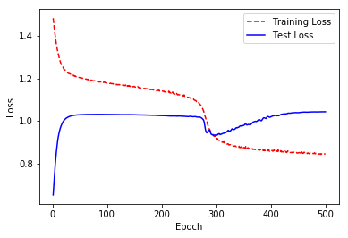

```python
# Get training and test loss histories
training_loss = history.history['loss']
test_loss = history.history['val_loss']

# Create count of the number of epochs
epoch_count = range(1, len(training_loss) + 1)

# Visualize loss history
plt.plot(epoch_count, training_loss, 'r--')
plt.plot(epoch_count, test_loss, 'b-')
plt.legend(['Training Loss', 'Test Loss'])
plt.xlabel('Epoch')
plt.ylabel('Loss')
plt.show();
```

```python
y_pred=model.predict(X_test)
```

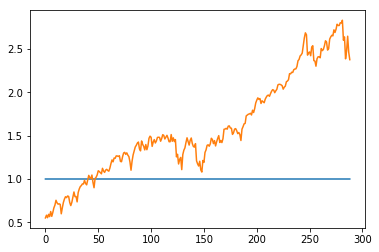

```python
plt.plot(y_pred)
plt.plot(y_test)
plt.show()
```

```python
print("RMSE of CNN on test set: ",np.sqrt(metrics.mean_squared_error(y_test,y_pred)))
```

```
RMSE of CNN on test set:  0.8224649537465623
```

LSTM

```python
inputs=Input(X_train.shape[1:])

x=LSTM(64,dropout=0.5,recurrent_dropout=0.5)(inputs)
x=BatchNormalization()(x)
# x=LSTM(64)(x)
x=Dense(128,activation='relu')(x)
# x=Dense(32)(x)
x=LeakyReLU()(x)
predictions=Dense(1,activation='sigmoid')(x)

model= Model(inputs=inputs,outputs=predictions)
model.compile(optimizer=Adam(lr=0.001), loss='mean_squared_error')
model.summary()
history=model.fit(X_train, y_train, validation_data=(X_val,y_val),
          batch_size=256,
          epochs=100,
          verbose=1)
```

```
_________________________________________________________________
Layer (type)                 Output Shape              Param #
=================================================================
input_3 (InputLayer)         (None, 5, 6)              0
_________________________________________________________________
lstm_1 (LSTM)                (None, 64)                18176
_________________________________________________________________
batch_normalization_3 (Batch (None, 64)                256
_________________________________________________________________
dense_5 (Dense)              (None, 128)               8320
_________________________________________________________________
leaky_re_lu_1 (LeakyReLU)    (None, 128)               0
_________________________________________________________________
dense_6 (Dense)              (None, 1)                 129
=================================================================
Total params: 26,881
Trainable params: 26,753
Non-trainable params: 128
_________________________________________________________________
Train on 866 samples, validate on 289 samples
```

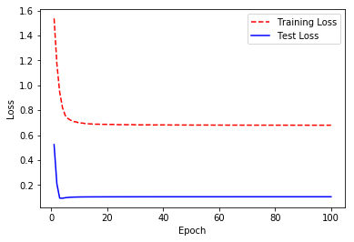

```python
# Get training and test loss histories
training_loss = history.history['loss']
test_loss = history.history['val_loss']

# Create count of the number of epochs
epoch_count = range(1, len(training_loss) + 1)

# Visualize loss history
plt.plot(epoch_count, training_loss, 'r--')
plt.plot(epoch_count, test_loss, 'b-')
plt.legend(['Training Loss', 'Test Loss'])
plt.xlabel('Epoch')
plt.ylabel('Loss')
plt.show();
```

```python
y_pred=model.predict(X_test)
```

```python
y_pred
```

[output not shown]

[output cut: 234 more lines]

[output not shown]

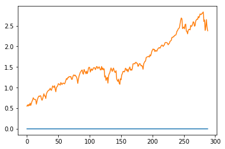

```python
plt.plot(y_pred)
plt.plot(y_test)
plt.show()
```

## Final thoughts

I figured all the models weren't performing that well, which might mean my feature selection wasn't that good. So I thought of just using today's price to use as a feature to predict tomorrow's price, and it turned out pretty well with just linear regression.

```python
X_data=np.array(data2.drop(['target'],axis=1))
# X_data=[float(i) for i in X_data]
X_data=X_data.astype(float)
print("Shape of X_data is: ", X_data.shape,'\nSneak peek on first five elements: \n', X_data[0:5])
```

```
Shape of X_data is:  (7228, 7)
Sneak peek on first five elements:
 [[359.69   17.24    7.93    7.875   7.847 399.     22.89 ]
 [358.76   18.19    7.974   7.927   7.911 395.     23.68 ]
 [355.67   19.22    7.972   7.91    7.9   396.5    23.41 ]
 [352.2    20.11    7.984   7.885   7.896 405.     23.08 ]
 [353.79   20.26    8.012   7.893   7.907 404.6    21.62 ]]
```

```python
y_data=np.array(data2.target)
y_data=[float(i) for i in y_data]
print("Length of y_data is :", len(y_data),'\nSneak peek on first five elements: \n', y_data[0:5])
```

```
Length of y_data is : 7228
Sneak peek on first five elements:
 [358.76, 355.67, 352.2, 353.79, 349.62]
```

```python
X_train=np.array(X_data[0:int(0.8*len(X_data))])
y_train=np.array(y_data[0:int(0.8*len(y_data))])
y_train_class=np.array(y_data_class[0:int(0.8*len(y_data_class))])
X_test=np.array(X_data[int(0.8*len(X_data)):])
y_test=np.array(y_data[int(0.8*len(y_data)):])
y_test_class=np.array(y_data_class[int(0.8*len(y_data_class)):])
```

```python
#Data Scaling
sc=StandardScaler()
sc2=StandardScaler()
X_train=sc.fit_transform(X_train)
X_test=sc.transform(X_test)
y_train=sc2.fit_transform(y_train.reshape(-1,1))
y_test=sc2.transform(y_test.reshape(-1,1))
X_data_sc=sc.fit_transform(X_data)
y_data_sc=sc.fit_transform(np.array(y_data).reshape(-1,1))
```

```python
from sklearn import linear_model
model=linear_model.LinearRegression()
model.fit(X_train,y_train)
```

```
LinearRegression(copy_X=True, fit_intercept=True, n_jobs=1, normalize=False)
```

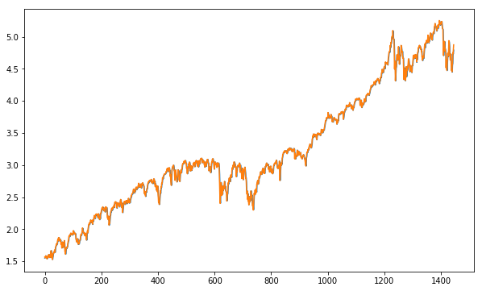

```
RMSE of test set:  0.046653871173250726
```

```python
#fit data to model and graph results
y_pred=model.predict(X_test)
figure(figsize=(10,6))
plt.plot(y_pred)
plt.plot(y_test)
plt.show()
print("RMSE of test set: ",np.sqrt(metrics.mean_squared_error(y_test,y_pred)))
```

## 4. Conclusion

In conclusion, even though many models seems to be complicated, they have their pros and cons.  
Complicated models doesn't directly imply that the results will be better.  
More importantly is the feature selection and hyperparameter tunings for me, since in this ipynb we can see that just by adding 1 feature drastically improved the predictions and reduced the RMSE by a lot.

References: Codes in course by professor Purewal Cardiologist-Level Arrhythmia Detection with Convolutional Neural Networks, Andrew Ng.(https://arxiv.org/pdf/1707.01836.pdf) Time Series Prediction with LSTM Recurrent Neural Networks in Python with Keras, Jason Brownlee (https://machinelearningmastery.com/time-series-prediction-lstm-recurrent-neural-networks-python-keras/) What is LightGBM, How to implement it? How to fine tune the parameters?, Pushkar Mandot (https://medium.com/@pushkarmandot/https-medium-com-pushkarmandot-what-is-lightgbm-how-to-implement-it-how-to-fine-tune-the-parameters-60347819b7fc)